# EDS 223: assignment 2

Elke Windschitl

2022-10-10

## introduction

The following exercises are modified from [Chapters 3](https://geocompr.robinlovelace.net/attr.html), [4](https://geocompr.robinlovelace.net/spatial-operations.html), [5](https://geocompr.robinlovelace.net/geometry-operations.html) of Geocomputation with R by Rovin Lovelace. Each question lists the total number of points. The breakdown of points can be found at the end of each instruction in parentheses. A general grading rubric can be found on the [course website](https://ryoliver.github.io/EDS_223_spatial_analysis/assignments.html).

Please update “author” to list your first and last names and any collaborators (e.g. Ruth Oliver, Friend1, Friend2).

**Due by midnight on Saturday 2022-10-22**

## prerequisites

```r
# add required packages here
library(sf)
library(spData)
library(tmap)
library(tidyverse)
library(rmapshaper)
```

## question 1

##### 5 points

Find the states that:(2.5)  
- belong to the West region  
- have an area below 250,000 square kilometers  
- and greater than 5,000,000 residents in 2015

```r
# Note: it looks like Alaska and Hawaii are not included here. I am not sure why, but this means they won't be included in my analysis.
# Change area from class units to class numeric
us_states$AREA <- as.numeric(us_states$AREA)

# Filter for the West region
target_states <- us_states %>%
  filter(REGION == "West") %>%
  # Filter for area
  filter(AREA < 250000) %>%
  # Filter for population
  filter(total_pop_15 > 5000000)
print(target_states)
```

```
## Simple feature collection with 1 feature and 6 fields
## Geometry type: MULTIPOLYGON
## Dimension:     XY
## Bounding box:  xmin: -124.7042 ymin: 45.54774 xmax: -116.916 ymax: 49.00236
## Geodetic CRS:  NAD83
##   GEOID       NAME REGION   AREA total_pop_10 total_pop_15
## 1    53 Washington   West 175436      6561297      6985464
##                         geometry
## 1 MULTIPOLYGON (((-122.7699 4...
```

```r
print(paste0("The only state that meets the above parameters is ", target_states$NAME))
```

```
## [1] "The only state that meets the above parameters is Washington"
```

What was the total population of the US in 2015? (2.5)

```r
# Find the sum of the populations
total_pop <- sum(us_states$total_pop_15)
# Print a statement
print(paste0("The total population of the continental US in 2015 was ", total_pop, " people."))
```

```
## [1] "The total population of the continental US in 2015 was 314375347 people."
```

## question 2

##### 5 points

Create a new variable named “us_states_stats” by adding variables from “us_states_df” to “us_states”. (3)

- Which function did you use and why? (0.5)
- Which variable is the key variable in both datasets? (0.5)
- What is the class of the new object? (0.5)
- Why does us_states_df have 2 more rows than us_states? (0.5)

```r
# Rename us_states state NAME to state
us_states <- us_states %>%
  rename(state = NAME)
# Join the data frames
us_states_stats <- left_join(us_states, us_states_df, by = "state")
class(us_states_stats)
```

```
## [1] "sf"         "data.frame"
```

```r
print("I used left_join because us_states doesn't include Alaska and Hawaii, but us_states_df does. The way the question was worded 'adding variables from us_states_df to us_states' made me think I should keep all observations from us_states and add only the relevant info from us_states_df to the already existing rows in us_states.")
```

[output not shown]

```r
print("The key variable in us_states was NAME but I changed it to state to match us_states_df. So, state was the key here.")
```

```
## [1] "The key variable in us_states was NAME but I changed it to state to match us_states_df. So, state was the key here."
```

```r
print("The class of the new object is an sf data frame.")
```

```
## [1] "The class of the new object is an sf data frame."
```

```r
print("As I mentioned above, us_states_df has two more rows than us_states because it includes Alaska and Hawaii.")
```

```
## [1] "As I mentioned above, us_states_df has two more rows than us_states because it includes Alaska and Hawaii."
```

## question 3

##### 10 points

Make a map of the percent change in population density between 2010 and 2015 in each state. Map should include a legend that is easily readable. (7)

```
## Variable(s) "pop_change" contains positive and negative values, so midpoint is set to 0. Set midpoint = NA to show the full spectrum of the color palette.
```

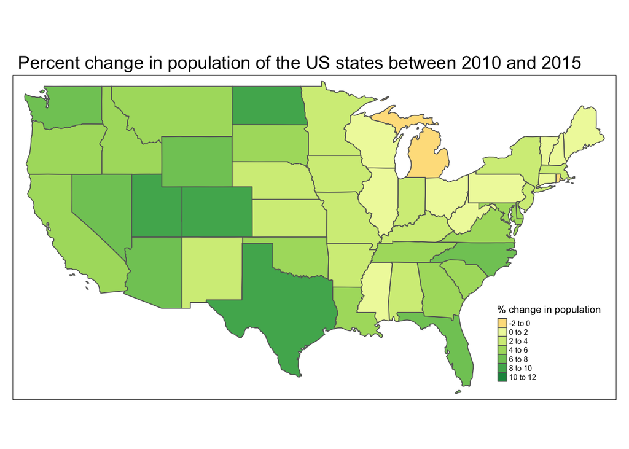

```r
# Add a column with the percent change of population for every state
us_states_stats <- us_states_stats %>%
  mutate(pop_change = ((total_pop_15 - total_pop_10)/total_pop_10 * 100), na.rm = TRUE)

# Create a map showing the percent change of every state's pop
tm_shape(us_states_stats) +
  tm_polygons(col = "pop_change",
              title = "% change in population") +
  tm_layout(legend.text.size = 0.5,
            legend.title.size = 0.8,
            legend.position = c(0.8, 0.05),
            main.title = "Percent change in population of the US states between 2010 and 2015",
            main.title.size = 1.2)
```

In how many states did population density decrease? (3)

```r
# Filter for states with negative population change
decreased <- us_states_stats %>%
  filter(pop_change < 0)
# Print a statement
print(paste0(length(decreased$state), " states had population density decreases. These states were ", decreased$state[1], " and ", decreased$state[2], "."))
```

```
## [1] "2 states had population density decreases. These states were Michigan and Rhode Island."
```

## question 4

##### 10 points

How many of New Zealand’s high points are in the Canterbury region? (5)

```r
# Find all high points in Canterbury
# Filter for the region Canterbury and make an object
canterbury <- nz %>%
  filter(Name == "Canterbury")

# Take the high points from Canterbury only
c_height <- nz_height[canterbury,]
# Print a statement
print(paste0(length(c_height$t50_fid), " high points are in the Canterbury region"))
```

```
## [1] "70 high points are in the Canterbury region"
```

Which region has the second highest number of “nz_height” points? And how many does it have? (5)

```r
# Join the regional nz data to the height points using a left join
region_points <- st_join(nz_height, nz, left = TRUE)
# Count the points in each region
counts <- as.data.frame(table(region_points$Name)) %>%
  arrange(desc(Freq))
# Print a statement
print(paste0("The region with the second highest number of nz_height points is ", counts[2,1], ", and it has ", counts[2,2], " high points within it."))
```

```
## [1] "The region with the second highest number of nz_height points is West Coast, and it has 22 high points within it."
```

## question 5

##### 15 points

Create a new object representing all of the states the geographically intersect with Colorado.(5)  
Hint: use the “united_states” dataset. The most concise way to do this is with the subsetting method “[”.  
Make a map of the resulting states. (2.5)

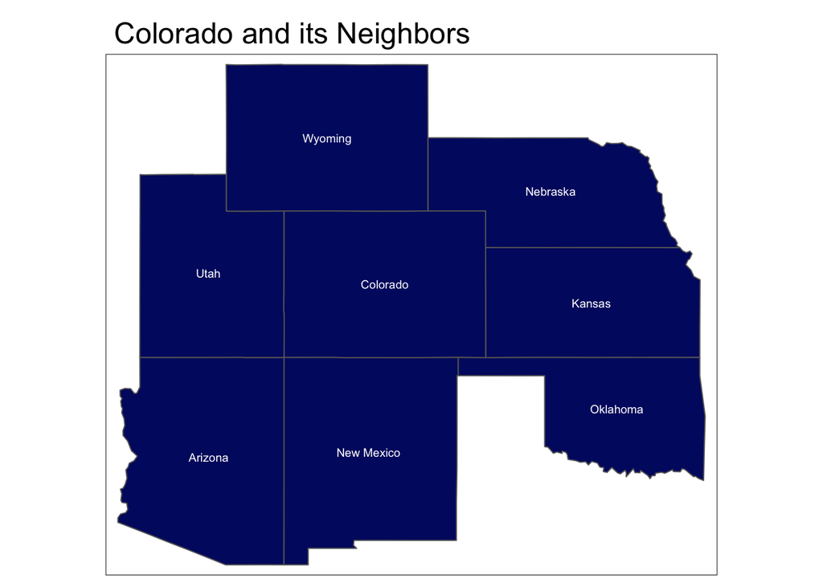

```r
# Create the object colorado
colorado <- us_states %>%
  filter(state == "Colorado")
# Create an object of colorado and all of its neighbors
co_neighbors <- us_states[colorado,]
# Map colorado and its neighbors
tm_shape(co_neighbors) +
  tm_polygons(col = "#02146e") +
  tm_layout(main.title = "Colorado and its Neighbors") +
  tm_text(text = "state",
          size = 0.6)
```

Create another object representing all the objects that touch (have a shared boundary with) Colorado and plot the result.(5)  
Hint: remember you can use the argument op = st_intersects and other spatial relations during spatial subsetting operations in base R).  
Make a map of the resulting states. (2.5)

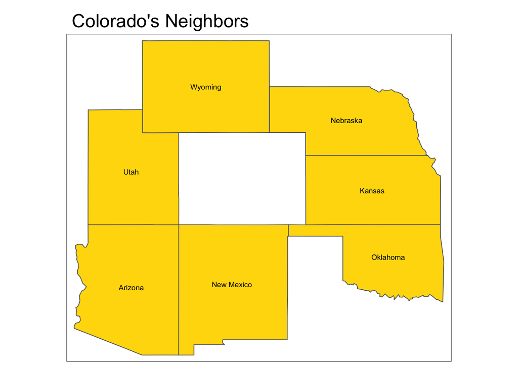

```r
# Create an object of the states that touch CO
touching_co <- us_states[colorado, op = st_touches]
# Map the states that touch CO
tm_shape(touching_co) +
  tm_polygons(col = "#ffda0a") +
  tm_layout(main.title = "Colorado's Neighbors") +
  tm_text(text = "state",
          size = 0.6)
```

## question 6

##### 10 points

Generate simplified versions of the “nz” dataset. Experiment with different values of keep (ranging from 0.5 to 0.00005) for **ms_simplify()** and dTolerance (from 100 to 100,000) **st_simplify()**. (5)

Map the results to show how the simplification changes as you change values.(5)

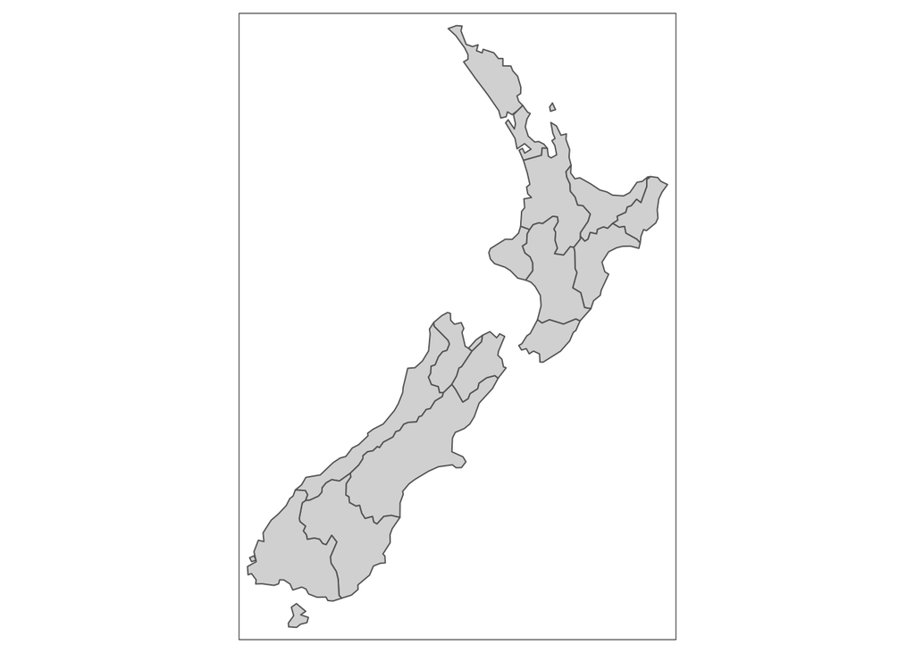

```r
# Simplify with keep of 0.5 with ms_simplify()
nz_simp <- ms_simplify(nz, keep = 0.5)
tm_shape(nz_simp) +
  tm_polygons()
```

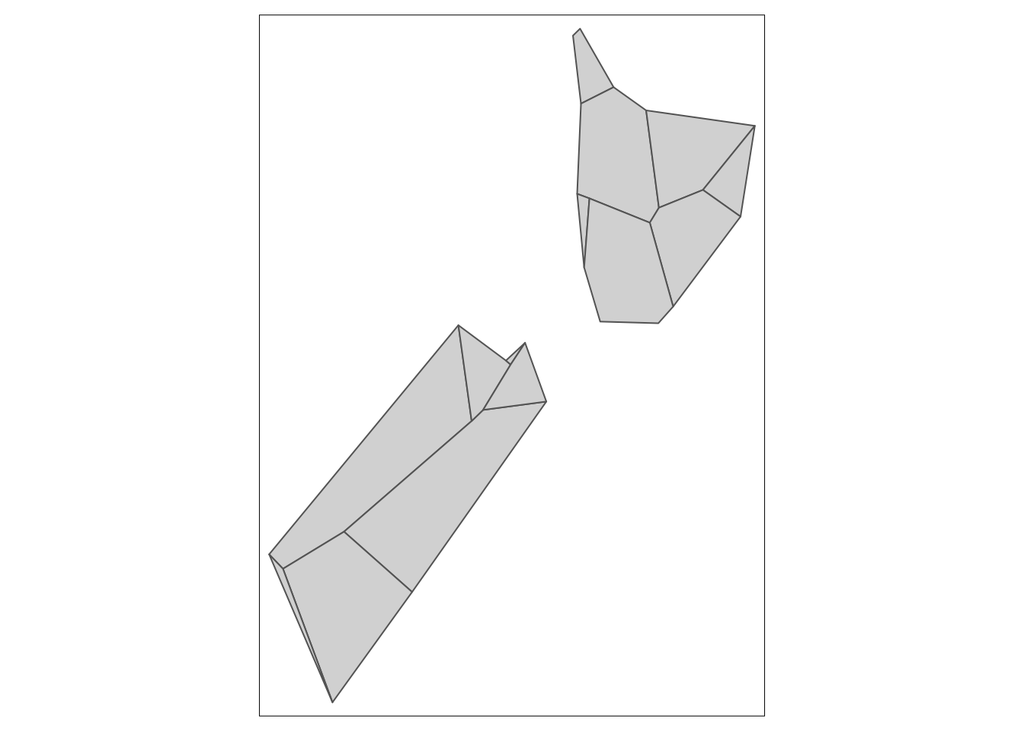

```r
# Simplitfy with keep of 0.00005 with ms_simplify()
nz_simp2 <- ms_simplify(nz, keep = 0.00005)
tm_shape(nz_simp2) +
  tm_polygons()
```

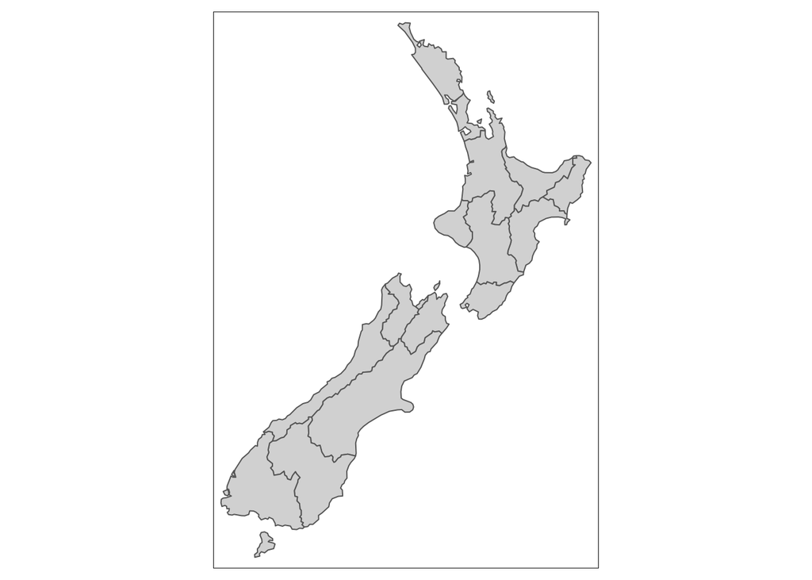

```r
# Simplify with dTolerance of 100 with st_simplify()
nz_simp3 <- st_simplify(nz, preserveTopology = TRUE, dTolerance = 100)
tm_shape(nz_simp3) +
  tm_polygons()
```

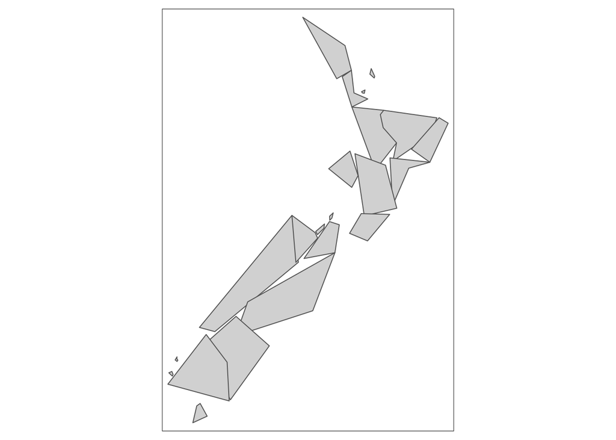

```r
# Simplify with dTolerance of 100,000 with st_simplify()
nz_simp4 <- st_simplify(nz, preserveTopology = TRUE, dTolerance = 100000)
tm_shape(nz_simp4) +
  tm_polygons()
```

```r
# The last one shows an error at this large dTolerance. I'm guessing I've smoothed so much that some polygons no longer exist. Forcing the polygons to remain intact with preserveTopology = TRUE seemed to work
```

## question 7

##### 10 points

How many points from the “nz_height” dataset are within 100km of the Canterbury region?

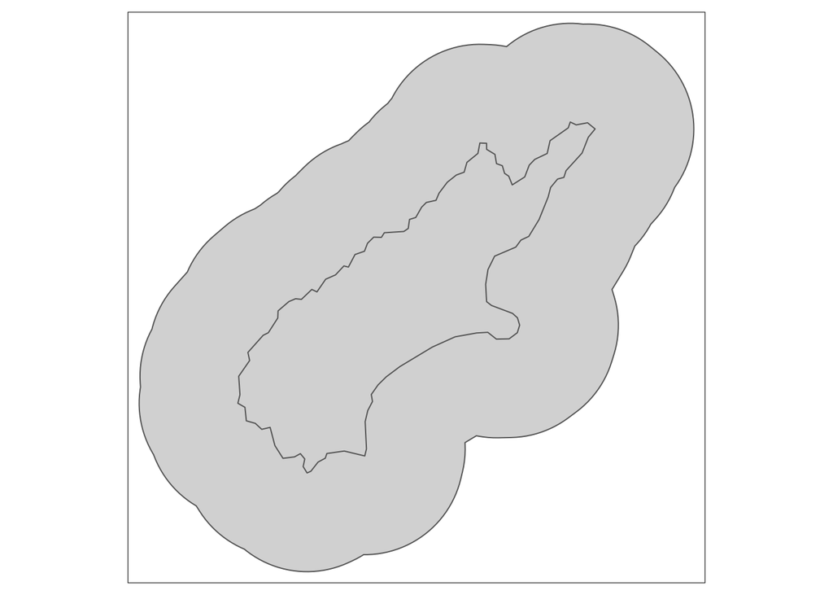

```r
# Create the 100K buffer, NZGD2000 is measured in meters
buff <- st_buffer(canterbury, dist = 100000)

# Plot the buffer vs Canterbury
tm_shape(buff) +
  tm_polygons() +
  tm_shape(canterbury) +
  tm_borders()
```

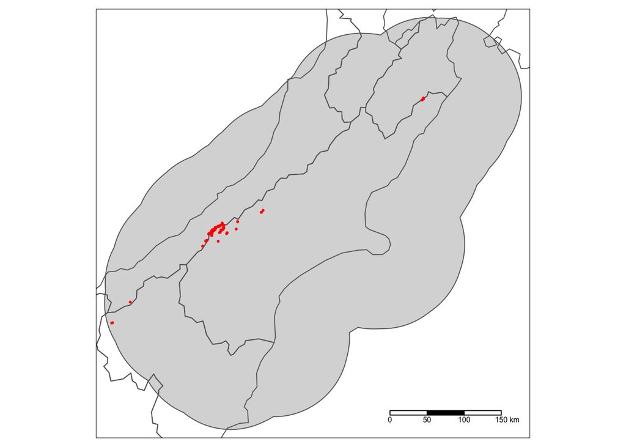

```r
# Take the height points from this buffer zone
buff_height <- nz_height[buff,]

#Plot
tm_shape(buff) +
  tm_polygons() +
  tm_shape(nz) +
  tm_borders() +
  tm_shape(buff_height) +
  tm_dots(col = "red") +
  tm_scale_bar()
```

```r
#Print a statement
print(paste0(length(buff_height$t50_fid)," height points are within 100km of Canterbury"))
```

```
## [1] "95 height points are within 100km of Canterbury"
```

## question 8

##### 15 points

Find the geographic centroid of the country of New Zealand. How far is it from the geographic centroid of Canterbury?

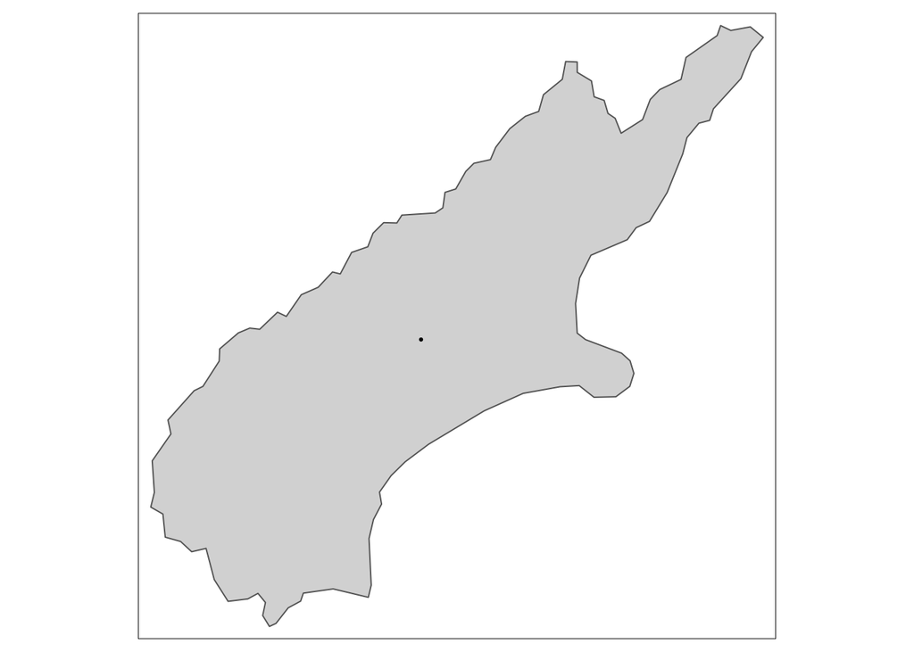

```r
# Find Canterbury's centriod
cant_centroid <- st_centroid(canterbury$geom)

# View the centriod
tm_shape(canterbury) +
  tm_polygons() +
  tm_shape(cant_centroid) +
  tm_dots()
```

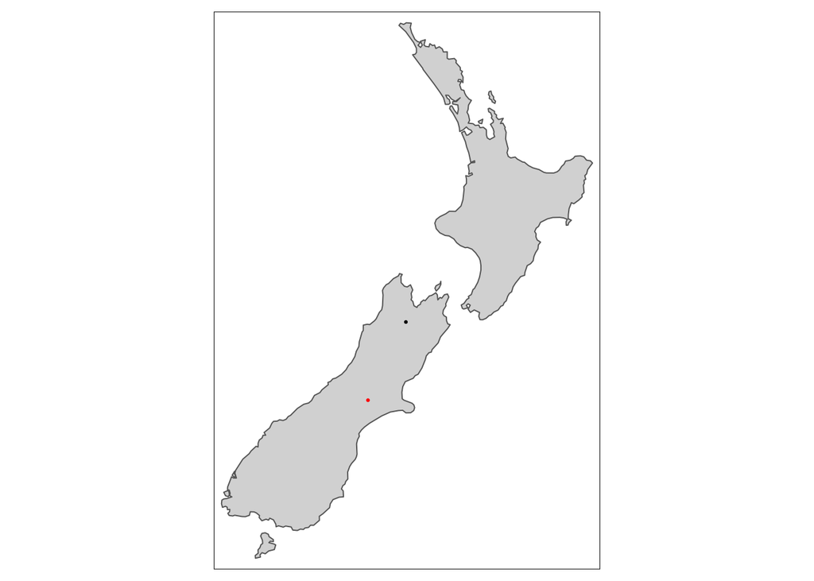

```r
# Find NZ centroid
NZ <- st_union(nz)
nz_centroid <- st_centroid(NZ)

# View the centroid
tm_shape(NZ) +
  tm_polygons() +
  tm_shape(nz_centroid) +
  tm_dots() +
  tm_shape(cant_centroid) +
  tm_dots(col = 'red')
```

```r
# Find the distance between the two centroids
dist <- st_distance(nz_centroid, cant_centroid)
dist
```

```
## Units: [m]
##          [,1]
## [1,] 234192.6
```

```r
# Print a statement
print(paste0("The distance between New Zealand's centroid and Canterbury's centroid is ", round(dist/1000), " kilometers."))
```

```
## [1] "The distance between New Zealand's centroid and Canterbury's centroid is 234 kilometers."
```